# Predict Bike Sharing Demand with AutoGluon Template

### Download and explore dataset

### Go to the bike sharing demand competition and agree to the terms

```python
# Download the dataset, it will be in a .zip file so you'll need to unzip it as well.
!kaggle competitions download -c bike-sharing-demand
# If you already downloaded it you can use the -o command to overwrite the file
!unzip -o bike-sharing-demand.zip
```

```python
# i have set everything up locally so i can skip everything above
```

```python
import pandas as pd
from autogluon.tabular import TabularPredictor
```

```python
# Create the train dataset in pandas by reading the csv
# Set the parsing of the datetime column so you can use some of the `dt` features in pandas later

# well i don't have to manually create all those 'dt' features because AutoGluon will automatically do it

train = pd.read_csv('train.csv')
train.head()
```

|  | datetime | season | holiday | workingday | weather | temp | atemp | humidity | windspeed | casual | registered | count |
| --- | --- | --- | --- | --- | --- | --- | --- | --- | --- | --- | --- | --- |
| 0 | 2011-01-01 00:00:00 | 1 | 0 | 0 | 1 | 9.84 | 14.395 | 81 | 0.0 | 3 | 13 | 16 |
| 1 | 2011-01-01 01:00:00 | 1 | 0 | 0 | 1 | 9.02 | 13.635 | 80 | 0.0 | 8 | 32 | 40 |
| 2 | 2011-01-01 02:00:00 | 1 | 0 | 0 | 1 | 9.02 | 13.635 | 80 | 0.0 | 5 | 27 | 32 |
| 3 | 2011-01-01 03:00:00 | 1 | 0 | 0 | 1 | 9.84 | 14.395 | 75 | 0.0 | 3 | 10 | 13 |
| 4 | 2011-01-01 04:00:00 | 1 | 0 | 0 | 1 | 9.84 | 14.395 | 75 | 0.0 | 0 | 1 | 1 |

```python
train.info()
```

```
<class 'pandas.core.frame.DataFrame'>
RangeIndex: 10886 entries, 0 to 10885
Data columns (total 12 columns):
 #   Column      Non-Null Count  Dtype
---  ------      --------------  -----
 0   datetime    10886 non-null  object
 1   season      10886 non-null  int64
 2   holiday     10886 non-null  int64
 3   workingday  10886 non-null  int64
 4   weather     10886 non-null  int64
 5   temp        10886 non-null  float64
 6   atemp       10886 non-null  float64
 7   humidity    10886 non-null  int64
 8   windspeed   10886 non-null  float64
 9   casual      10886 non-null  int64
 10  registered  10886 non-null  int64
 11  count       10886 non-null  int64
dtypes: float64(3), int64(8), object(1)
memory usage: 1020.7+ KB
```

```python
# Simple output of the train dataset to view some of the min/max/varition of the dataset features.

train.describe()
```

|  | season | holiday | workingday | weather | temp | atemp | humidity | windspeed | casual | registered | count |
| --- | --- | --- | --- | --- | --- | --- | --- | --- | --- | --- | --- |
| count | 10886.000000 | 10886.000000 | 10886.000000 | 10886.000000 | 10886.00000 | 10886.000000 | 10886.000000 | 10886.000000 | 10886.000000 | 10886.000000 | 10886.000000 |
| mean | 2.506614 | 0.028569 | 0.680875 | 1.418427 | 20.23086 | 23.655084 | 61.886460 | 12.799395 | 36.021955 | 155.552177 | 191.574132 |
| std | 1.116174 | 0.166599 | 0.466159 | 0.633839 | 7.79159 | 8.474601 | 19.245033 | 8.164537 | 49.960477 | 151.039033 | 181.144454 |
| min | 1.000000 | 0.000000 | 0.000000 | 1.000000 | 0.82000 | 0.760000 | 0.000000 | 0.000000 | 0.000000 | 0.000000 | 1.000000 |
| 25% | 2.000000 | 0.000000 | 0.000000 | 1.000000 | 13.94000 | 16.665000 | 47.000000 | 7.001500 | 4.000000 | 36.000000 | 42.000000 |
| 50% | 3.000000 | 0.000000 | 1.000000 | 1.000000 | 20.50000 | 24.240000 | 62.000000 | 12.998000 | 17.000000 | 118.000000 | 145.000000 |
| 75% | 4.000000 | 0.000000 | 1.000000 | 2.000000 | 26.24000 | 31.060000 | 77.000000 | 16.997900 | 49.000000 | 222.000000 | 284.000000 |
| max | 4.000000 | 1.000000 | 1.000000 | 4.000000 | 41.00000 | 45.455000 | 100.000000 | 56.996900 | 367.000000 | 886.000000 | 977.000000 |

```python
# make a copy and do some munging so we can check the correlation

train_copy = train.copy()
train_copy = train_copy.drop(columns=['datetime'])
train_copy.corr()

# these are highly correlated:
#   - dt_month, season
#   - atemp, temp
#   - count, registered
# dt_day range in the train set is (1, 19), but we need to predict dt_day in this range (20, 31), should we remove it?
```

|  | season | holiday | workingday | weather | temp | atemp | humidity | windspeed | casual | registered | count |
| --- | --- | --- | --- | --- | --- | --- | --- | --- | --- | --- | --- |
| season | 1.000000 | 0.029368 | -0.008126 | 0.008879 | 0.258689 | 0.264744 | 0.190610 | -0.147121 | 0.096758 | 0.164011 | 0.163439 |
| holiday | 0.029368 | 1.000000 | -0.250491 | -0.007074 | 0.000295 | -0.005215 | 0.001929 | 0.008409 | 0.043799 | -0.020956 | -0.005393 |
| workingday | -0.008126 | -0.250491 | 1.000000 | 0.033772 | 0.029966 | 0.024660 | -0.010880 | 0.013373 | -0.319111 | 0.119460 | 0.011594 |
| weather | 0.008879 | -0.007074 | 0.033772 | 1.000000 | -0.055035 | -0.055376 | 0.406244 | 0.007261 | -0.135918 | -0.109340 | -0.128655 |
| temp | 0.258689 | 0.000295 | 0.029966 | -0.055035 | 1.000000 | 0.984948 | -0.064949 | -0.017852 | 0.467097 | 0.318571 | 0.394454 |
| atemp | 0.264744 | -0.005215 | 0.024660 | -0.055376 | 0.984948 | 1.000000 | -0.043536 | -0.057473 | 0.462067 | 0.314635 | 0.389784 |
| humidity | 0.190610 | 0.001929 | -0.010880 | 0.406244 | -0.064949 | -0.043536 | 1.000000 | -0.318607 | -0.348187 | -0.265458 | -0.317371 |
| windspeed | -0.147121 | 0.008409 | 0.013373 | 0.007261 | -0.017852 | -0.057473 | -0.318607 | 1.000000 | 0.092276 | 0.091052 | 0.101369 |
| casual | 0.096758 | 0.043799 | -0.319111 | -0.135918 | 0.467097 | 0.462067 | -0.348187 | 0.092276 | 1.000000 | 0.497250 | 0.690414 |
| registered | 0.164011 | -0.020956 | 0.119460 | -0.109340 | 0.318571 | 0.314635 | -0.265458 | 0.091052 | 0.497250 | 1.000000 | 0.970948 |
| count | 0.163439 | -0.005393 | 0.011594 | -0.128655 | 0.394454 | 0.389784 | -0.317371 | 0.101369 | 0.690414 | 0.970948 | 1.000000 |

```
array([[<Axes: title={'center': 'season'}>,
        <Axes: title={'center': 'holiday'}>,
        <Axes: title={'center': 'workingday'}>],
       [<Axes: title={'center': 'weather'}>,
        <Axes: title={'center': 'temp'}>,
        <Axes: title={'center': 'atemp'}>],
       [<Axes: title={'center': 'humidity'}>,
        <Axes: title={'center': 'windspeed'}>,
        <Axes: title={'center': 'casual'}>],
       [<Axes: title={'center': 'registered'}>,
        <Axes: title={'center': 'count'}>, <Axes: >]], dtype=object)
```

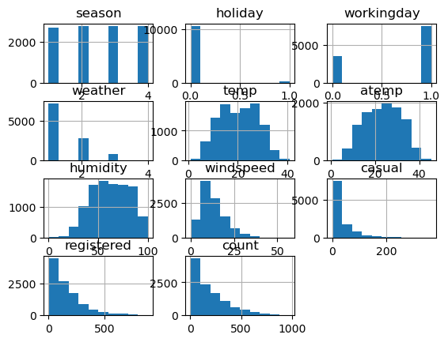

```python
train.hist() # it will auto skip non-numeric features

# holiday is almost always 0
```

```python
# Create the test pandas dataframe in pandas by reading the csv, remember to parse the datetime!

test = pd.read_csv('test.csv')
test.head()
```

|  | datetime | season | holiday | workingday | weather | temp | atemp | humidity | windspeed |
| --- | --- | --- | --- | --- | --- | --- | --- | --- | --- |
| 0 | 2011-01-20 00:00:00 | 1 | 0 | 1 | 1 | 10.66 | 11.365 | 56 | 26.0027 |
| 1 | 2011-01-20 01:00:00 | 1 | 0 | 1 | 1 | 10.66 | 13.635 | 56 | 0.0000 |
| 2 | 2011-01-20 02:00:00 | 1 | 0 | 1 | 1 | 10.66 | 13.635 | 56 | 0.0000 |
| 3 | 2011-01-20 03:00:00 | 1 | 0 | 1 | 1 | 10.66 | 12.880 | 56 | 11.0014 |
| 4 | 2011-01-20 04:00:00 | 1 | 0 | 1 | 1 | 10.66 | 12.880 | 56 | 11.0014 |

```python
test.describe()
```

|  | season | holiday | workingday | weather | temp | atemp | humidity | windspeed |
| --- | --- | --- | --- | --- | --- | --- | --- | --- |
| count | 6493.000000 | 6493.000000 | 6493.000000 | 6493.000000 | 6493.000000 | 6493.000000 | 6493.000000 | 6493.000000 |
| mean | 2.493300 | 0.029108 | 0.685815 | 1.436778 | 20.620607 | 24.012865 | 64.125212 | 12.631157 |
| std | 1.091258 | 0.168123 | 0.464226 | 0.648390 | 8.059583 | 8.782741 | 19.293391 | 8.250151 |
| min | 1.000000 | 0.000000 | 0.000000 | 1.000000 | 0.820000 | 0.000000 | 16.000000 | 0.000000 |
| 25% | 2.000000 | 0.000000 | 0.000000 | 1.000000 | 13.940000 | 16.665000 | 49.000000 | 7.001500 |
| 50% | 3.000000 | 0.000000 | 1.000000 | 1.000000 | 21.320000 | 25.000000 | 65.000000 | 11.001400 |
| 75% | 3.000000 | 0.000000 | 1.000000 | 2.000000 | 27.060000 | 31.060000 | 81.000000 | 16.997900 |
| max | 4.000000 | 1.000000 | 1.000000 | 4.000000 | 40.180000 | 50.000000 | 100.000000 | 55.998600 |

```python
test.info()
```

```
<class 'pandas.core.frame.DataFrame'>
RangeIndex: 6493 entries, 0 to 6492
Data columns (total 9 columns):
 #   Column      Non-Null Count  Dtype
---  ------      --------------  -----
 0   datetime    6493 non-null   object
 1   season      6493 non-null   int64
 2   holiday     6493 non-null   int64
 3   workingday  6493 non-null   int64
 4   weather     6493 non-null   int64
 5   temp        6493 non-null   float64
 6   atemp       6493 non-null   float64
 7   humidity    6493 non-null   int64
 8   windspeed   6493 non-null   float64
dtypes: float64(3), int64(5), object(1)
memory usage: 456.7+ KB
```

```python
# Same thing as train and test dataset

submission = pd.read_csv('sampleSubmission.csv')
submission.head()
```

|  | datetime | count |
| --- | --- | --- |
| 0 | 2011-01-20 00:00:00 | 0 |
| 1 | 2011-01-20 01:00:00 | 0 |
| 2 | 2011-01-20 02:00:00 | 0 |
| 3 | 2011-01-20 03:00:00 | 0 |
| 4 | 2011-01-20 04:00:00 | 0 |

```python
submission.info()
```

```
<class 'pandas.core.frame.DataFrame'>
RangeIndex: 6493 entries, 0 to 6492
Data columns (total 2 columns):
 #   Column    Non-Null Count  Dtype
---  ------    --------------  -----
 0   datetime  6493 non-null   object
 1   count     6493 non-null   int64
dtypes: int64(1), object(1)
memory usage: 101.6+ KB
```

## Step 3: Train a model using AutoGluon’s Tabular Prediction

Requirements:

- We are prediting `count`, so it is the label we are setting.
- Ignore `casual` and `registered` columns as they are also not present in the test dataset.
- Use the `root_mean_squared_error` as the metric to use for evaluation.
- Set a time limit of 10 minutes (600 seconds).
- Use the preset `best_quality` to focus on creating the best model.

```python
train = train.drop(columns=['casual', 'registered'])

predictor = TabularPredictor(label="count", eval_metric="root_mean_squared_error").fit(train_data=train, time_limit=600, presets="best_quality")
```

[output not shown]

[output cut: 395 more lines]

```
	-55.3021	 = Validation score   (-root_mean_squared_error)
	5.62s	 = Training   runtime
	2.22s	 = Validation runtime
Fitting model: NeuralNetFastAI_r191_BAG_L2 ... Training model for up to 7.66s of the 7.58s of remaining time.
	Fitting 8 child models (S1F1 - S1F8) | Fitting with ParallelLocalFoldFittingStrategy (8 workers, per: cpus=1, gpus=0, memory=0.14%)
	-61.6041	 = Validation score   (-root_mean_squared_error)
	8.19s	 = Training   runtime
	0.19s	 = Validation runtime
Fitting model: WeightedEnsemble_L3 ... Training model for up to 360.0s of the -2.6s of remaining time.
	Ensemble Weights: {'NeuralNetTorch_r79_BAG_L2': 0.321, 'NeuralNetFastAI_BAG_L2': 0.282, 'RandomForestMSE_BAG_L2': 0.231, 'NeuralNetTorch_BAG_L2': 0.128, 'ExtraTreesMSE_BAG_L2': 0.038}
	-49.7731	 = Validation score   (-root_mean_squared_error)
	0.47s	 = Training   runtime
	0.0s	 = Validation runtime
AutoGluon training complete, total runtime = 444.1s ... Best model: "WeightedEnsemble_L3"
TabularPredictor saved. To load, use: predictor = TabularPredictor.load("AutogluonModels/ag-20240927_003648")
```

### Review AutoGluon's training run with ranking of models that did the best.

```python
predictor.fit_summary()
```

```
*** Summary of fit() ***
Estimated performance of each model:
                          model   score_val              eval_metric  pred_time_val    fit_time  pred_time_val_marginal  fit_time_marginal  stack_level  can_infer  fit_order
0           WeightedEnsemble_L3  -49.773130  root_mean_squared_error      21.504795  337.244912                0.000193           0.466703            3       True         38
1        NeuralNetFastAI_BAG_L2  -51.723926  root_mean_squared_error      20.685654  270.615091                0.066469           6.657891            2       True         30
2     NeuralNetTorch_r79_BAG_L2  -51.771455  root_mean_squared_error      20.738537  295.015344                0.119352          31.058144            2       True         35
3        RandomForestMSE_BAG_L2  -53.322978  root_mean_squared_error      20.922953  270.000498                0.303768           6.043298            2       True         27
4         NeuralNetTorch_BAG_L2  -54.547211  root_mean_squared_error      20.716823  291.544291                0.097638          27.587091            2       True         32
5          ExtraTreesMSE_BAG_L2  -54.633403  root_mean_squared_error      20.917375  265.431785                0.298190           1.474585            2       True         29
6          LightGBMLarge_BAG_L2  -54.634721  root_mean_squared_error      20.867803  267.934208                0.248618           3.977008            2       True         33
7               LightGBM_BAG_L2  -54.788064  root_mean_squared_error      20.863179  266.365682                0.243994           2.408482            2       True         26
8                XGBoost_BAG_L2  -54.841965  root_mean_squared_error      20.668384  266.909661                0.049199           2.952461            2       True         31
9          LightGBM_r131_BAG_L2  -55.302113  root_mean_squared_error      22.834882  269.579398                2.215697           5.622198            2       True         36
10              CatBoost_BAG_L2  -55.899308  root_mean_squared_error      20.634160  282.110969                0.014975          18.153769            2       True         28
11         CatBoost_r177_BAG_L2  -56.136517  root_mean_squared_error      20.633410  275.191300                0.014225          11.234100            2       True         34
```

[output cut: 39 more lines]

[output not shown]

[output cut: 416 more lines]

```
 23            1       True         11
 24            1       True          6
 25            1       True         12
 26            1       True          4
 27            1       True          3
 28            1       True         23
 29            1       True          9
 30            1       True         21
 31            1       True         15
 32            1       True         17
 33            1       True          8
 34            1       True         22
 35            1       True         18
 36            1       True         10
 37            1       True         13  }
```

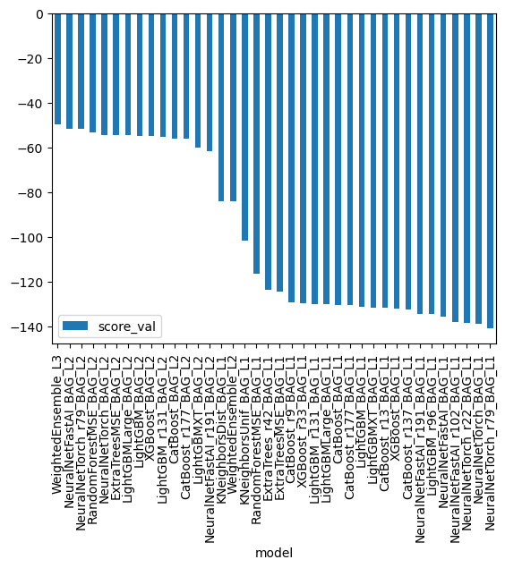

```python
predictor.leaderboard(silent=True).plot(kind="bar", x="model", y="score_val")
```

### Create predictions from test dataset

```python
predictions = predictor.predict(test)
predictions.head()
```

```
0    25.528347
1    40.692253
2    46.424694
3    49.430664
4    51.857288
Name: count, dtype: float32
```

#### NOTE: Kaggle will reject the submission if we don't set everything to be > 0.

```python
# Describe the `predictions` series to see if there are any negative values

predictions.describe()
```

```
count    6493.000000
mean       98.741394
std        89.249054
min         3.061394
25%        19.073130
50%        63.277786
75%       167.791687
max       351.193085
Name: count, dtype: float64
```

```python
# How many negative values do we have?

# we can see from describe() above there is no negative value

neg_count = 0
for prediction in list(predictions):
    if prediction < 0:
        neg_count += 1
print(neg_count)
```

```
0
```

```python
# Set them to zero

# no need to do this
```

### Set predictions to submission dataframe, save, and submit

```python
submission["count"] = predictions
submission["count"] = submission["count"].astype("int") # convert predictions to integers

submission.to_csv("submission.csv", index=False)
```

```python
!kaggle competitions submit -c bike-sharing-demand -f submission.csv -m "first raw submission"
```

```
Successfully submitted to Bike Sharing Demand
```

#### View submission via the command line or in the web browser under the competition's page - `My Submissions`

```python
!kaggle competitions submissions -c bike-sharing-demand | tail -n +1 | head -n 3
```

```
fileName                     date                 description                        status    publicScore  privateScore
---------------------------  -------------------  ---------------------------------  --------  -----------  ------------
submission.csv               2024-09-27 00:58:35  first raw submission               complete  1.83797      1.83797
```

#### Initial score of `1.83797`

## Step 4: Exploratory Data Analysis and Creating an additional feature

- Any additional feature will do, but a great suggestion would be to separate out the datetime into hour, day, or month parts.

```
array([[<Axes: title={'center': 'season'}>,
        <Axes: title={'center': 'holiday'}>,
        <Axes: title={'center': 'workingday'}>],
       [<Axes: title={'center': 'weather'}>,
        <Axes: title={'center': 'temp'}>,
        <Axes: title={'center': 'atemp'}>],
       [<Axes: title={'center': 'humidity'}>,
        <Axes: title={'center': 'windspeed'}>,
        <Axes: title={'center': 'count'}>]], dtype=object)
```

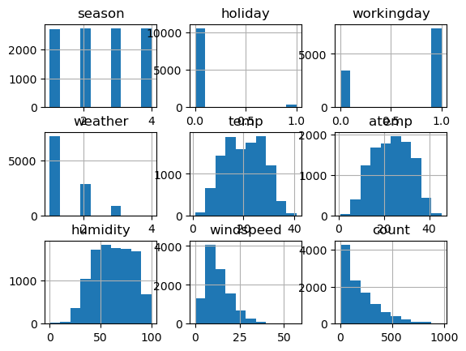

```python
# Create a histogram of all features to show the distribution of each one relative to the data. This is part of the exploritory data analysis

# i ran this already, but can run again, this time without the 2 features ('casual', registered')

train.hist()
```

```python
# create a new feature

train['dt_year'] = pd.to_datetime(train['datetime']).dt.year
train['dt_month'] = pd.to_datetime(train['datetime']).dt.month
train['dt_day'] = pd.to_datetime(train['datetime']).dt.day
train['dt_dow'] = pd.to_datetime(train['datetime']).dt.day_of_week
train['dt_hour'] = pd.to_datetime(train['datetime']).dt.hour

train = train.drop(columns = ['datetime'])

test['dt_year'] = pd.to_datetime(test['datetime']).dt.year
test['dt_month'] = pd.to_datetime(test['datetime']).dt.month
test['dt_day'] = pd.to_datetime(test['datetime']).dt.day
test['dt_dow'] = pd.to_datetime(test['datetime']).dt.day_of_week
test['dt_hour'] = pd.to_datetime(test['datetime']).dt.hour

test = test.drop(columns = ['datetime'])
```

## Make category types for these so models know they are not just numbers

- AutoGluon originally sees these as ints, but in reality they are int representations of a category.
- Setting the dtype to category will classify these as categories in AutoGluon.

```python
train["season"] = train["season"].astype("category")
train["weather"] = train["weather"].astype("category")

test["season"] = test["season"].astype("category")
test["weather"] = test["weather"].astype("category")
```

```python
# View are new feature

train.head()
```

|  | season | holiday | workingday | weather | temp | atemp | humidity | windspeed | count | dt_year | dt_month | dt_day | dt_dow | dt_hour |
| --- | --- | --- | --- | --- | --- | --- | --- | --- | --- | --- | --- | --- | --- | --- |
| 0 | 1 | 0 | 0 | 1 | 9.84 | 14.395 | 81 | 0.0 | 16 | 2011 | 1 | 1 | 5 | 0 |
| 1 | 1 | 0 | 0 | 1 | 9.02 | 13.635 | 80 | 0.0 | 40 | 2011 | 1 | 1 | 5 | 1 |
| 2 | 1 | 0 | 0 | 1 | 9.02 | 13.635 | 80 | 0.0 | 32 | 2011 | 1 | 1 | 5 | 2 |
| 3 | 1 | 0 | 0 | 1 | 9.84 | 14.395 | 75 | 0.0 | 13 | 2011 | 1 | 1 | 5 | 3 |
| 4 | 1 | 0 | 0 | 1 | 9.84 | 14.395 | 75 | 0.0 | 1 | 2011 | 1 | 1 | 5 | 4 |

```
array([[<Axes: title={'center': 'holiday'}>,
        <Axes: title={'center': 'workingday'}>,
        <Axes: title={'center': 'temp'}>],
       [<Axes: title={'center': 'atemp'}>,
        <Axes: title={'center': 'humidity'}>,
        <Axes: title={'center': 'windspeed'}>],
       [<Axes: title={'center': 'count'}>,
        <Axes: title={'center': 'dt_year'}>,
        <Axes: title={'center': 'dt_month'}>],
       [<Axes: title={'center': 'dt_day'}>,
        <Axes: title={'center': 'dt_dow'}>,
        <Axes: title={'center': 'dt_hour'}>]], dtype=object)
```

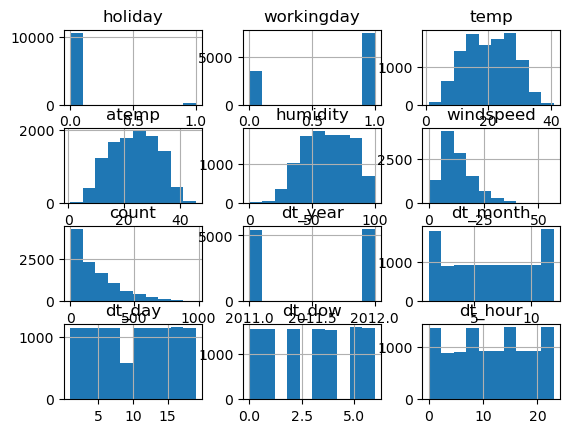

```python
# View histogram of all features again now with the hour feature

train.hist()
```

## Step 5: Rerun the model with the same settings as before, just with more features

```python
predictor_new_features = TabularPredictor(label="count", eval_metric="root_mean_squared_error").fit(train_data=train, time_limit=600, presets="best_quality")
```

[output not shown]

[output cut: 188 more lines]

```
	-32.1921	 = Validation score   (-root_mean_squared_error)
	16.05s	 = Training   runtime
	0.03s	 = Validation runtime
Fitting model: LightGBM_r96_BAG_L2 ... Training model for up to 6.78s of the 6.73s of remaining time.
	Fitting 8 child models (S1F1 - S1F8) | Fitting with ParallelLocalFoldFittingStrategy (8 workers, per: cpus=1, gpus=0, memory=0.07%)
	-32.7412	 = Validation score   (-root_mean_squared_error)
	2.97s	 = Training   runtime
	0.67s	 = Validation runtime
Fitting model: WeightedEnsemble_L3 ... Training model for up to 360.0s of the 1.84s of remaining time.
	Ensemble Weights: {'NeuralNetFastAI_r191_BAG_L2': 0.282, 'RandomForestMSE_BAG_L2': 0.205, 'NeuralNetTorch_r79_BAG_L2': 0.179, 'LightGBM_BAG_L2': 0.154, 'CatBoost_BAG_L2': 0.077, 'CatBoost_r177_BAG_L1': 0.051, 'NeuralNetTorch_BAG_L1': 0.038, 'CatBoost_r9_BAG_L2': 0.013}
	-31.7249	 = Validation score   (-root_mean_squared_error)
	0.26s	 = Training   runtime
	0.0s	 = Validation runtime
AutoGluon training complete, total runtime = 433.45s ... Best model: "WeightedEnsemble_L3"
TabularPredictor saved. To load, use: predictor = TabularPredictor.load("AutogluonModels/ag-20240927_005927")
```

```python
predictor_new_features.fit_summary()
```

```
*** Summary of fit() ***
Estimated performance of each model:
                          model   score_val              eval_metric  pred_time_val    fit_time  pred_time_val_marginal  fit_time_marginal  stack_level  can_infer  fit_order
0           WeightedEnsemble_L3  -31.724897  root_mean_squared_error      34.885833  347.182485                0.000198           0.263496            3       True         34
1           WeightedEnsemble_L2  -32.038903  root_mean_squared_error       9.133873  179.401701                0.000167           0.187961            2       True         18
2   NeuralNetFastAI_r191_BAG_L2  -32.097179  root_mean_squared_error      34.339027  290.400034                0.201286          24.194130            2       True         31
3            CatBoost_r9_BAG_L2  -32.192070  root_mean_squared_error      34.172481  282.254498                0.034740          16.048594            2       True         32
4               LightGBM_BAG_L2  -32.268704  root_mean_squared_error      34.181040  268.302121                0.043299           2.096217            2       True         20
5          ExtraTreesMSE_BAG_L2  -32.292800  root_mean_squared_error      34.440891  267.413013                0.303150           1.207109            2       True         23
6        NeuralNetFastAI_BAG_L2  -32.320630  root_mean_squared_error      34.217240  273.657376                0.079499           7.451471            2       True         24
7               CatBoost_BAG_L2  -32.361171  root_mean_squared_error      34.179050  275.322558                0.041309           9.116653            2       True         22
8          LightGBM_r131_BAG_L2  -32.365933  root_mean_squared_error      34.414339  268.800305                0.276598           2.594400            2       True         30
9        RandomForestMSE_BAG_L2  -32.455639  root_mean_squared_error      34.451085  271.413668                0.313344           5.207764            2       True         21
10    NeuralNetTorch_r79_BAG_L2  -32.481606  root_mean_squared_error      34.251657  290.255631                0.113916          24.049727            2       True         29
11         CatBoost_r177_BAG_L2  -32.604754  root_mean_squared_error      34.154866  270.482640                0.017125           4.276735            2       True         28
12               XGBoost_BAG_L2  -32.622431  root_mean_squared_error      34.181772  268.064945                0.044031           1.859040            2       True         25
13          LightGBM_r96_BAG_L2  -32.741157  root_mean_squared_error      34.804250  269.175232                0.666509           2.969327            2       True         33
14            LightGBMXT_BAG_L2  -32.928172  root_mean_squared_error      34.300334  268.389889                0.162593           2.183985            2       True         19
15         LightGBMLarge_BAG_L2  -32.997728  root_mean_squared_error      34.300246  269.102826                0.162505           2.896921            2       True         27
16        NeuralNetTorch_BAG_L2  -33.438397  root_mean_squared_error      34.226767  278.611135                0.089026          12.405230            2       True         26
17           CatBoost_r9_BAG_L1  -33.469309  root_mean_squared_error       0.150876   30.451074                0.150876          30.451074            1       True         16
18         LightGBM_r131_BAG_L1  -33.816162  root_mean_squared_error      13.096263    7.156131               13.096263           7.156131            1       True         14
19         CatBoost_r177_BAG_L1  -33.839757  root_mean_squared_error       0.033666   27.742172                0.033666          27.742172            1       True         12
20              CatBoost_BAG_L1  -33.983187  root_mean_squared_error       0.085583   73.018704                0.085583          73.018704            1       True          6
21         LightGBMLarge_BAG_L1  -34.062039  root_mean_squared_error       0.997138    3.891149                0.997138           3.891149            1       True         11
22              LightGBM_BAG_L1  -34.439520  root_mean_squared_error       1.496585    3.479188                1.496585           3.479188            1       True          4
23            LightGBMXT_BAG_L1  -34.621353  root_mean_squared_error       6.328969    5.736161                6.328969           5.736161            1       True          3
24               XGBoost_BAG_L1  -35.901618  root_mean_squared_error       0.442503    2.505738                0.442503           2.505738            1       True          9
25          LightGBM_r96_BAG_L1  -38.530978  root_mean_squared_error      10.466959    5.621137               10.466959           5.621137            1       True         17
26         ExtraTreesMSE_BAG_L1  -38.908750  root_mean_squared_error       0.256245    0.620546                0.256245           0.620546            1       True          7
27       RandomForestMSE_BAG_L1  -38.996439  root_mean_squared_error       0.268734    1.197640                0.268734           1.197640            1       True          5
28        NeuralNetTorch_BAG_L1  -40.329756  root_mean_squared_error       0.040889   34.895292                0.040889          34.895292            1       True         10
29  NeuralNetFastAI_r191_BAG_L1  -43.138324  root_mean_squared_error       0.201197   23.532641                0.201197          23.532641            1       True         15
```

[output cut: 17 more lines]

[output not shown]

[output cut: 367 more lines]

```
 19            1       True         12
 20            1       True          6
 21            1       True         11
 22            1       True          4
 23            1       True          3
 24            1       True          9
 25            1       True         17
 26            1       True          7
 27            1       True          5
 28            1       True         10
 29            1       True         15
 30            1       True          8
 31            1       True         13
 32            1       True          2
 33            1       True          1  }
```

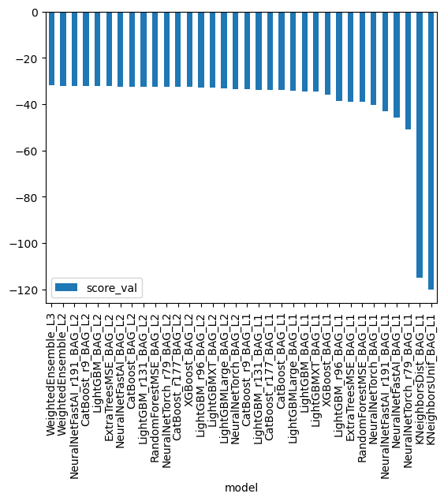

```python
predictor_new_features.leaderboard(silent=True).plot(kind="bar", x="model", y="score_val")
```

```python
predictions_new_features = predictor_new_features.predict(test)
```

```python
predictions_new_features.describe()
```

```
count    6493.000000
mean      188.337479
std       171.609940
min         0.526113
25%        46.495949
50%       146.081299
75%       276.396729
max       888.192383
Name: count, dtype: float64
```

```python
# Remember to set all negative values to zero

# no need to do this either
```

```python
# Same submitting predictions

submission_new_features = pd.read_csv('sampleSubmission.csv')

submission_new_features["count"] = predictions_new_features
submission_new_features["count"] = submission_new_features["count"].astype("int")

submission_new_features.to_csv("submission_new_features.csv", index=False)
```

```python
!kaggle competitions submit -c bike-sharing-demand -f submission_new_features.csv -m "new features"
```

```
Successfully submitted to Bike Sharing Demand
```

```python
!kaggle competitions submissions -c bike-sharing-demand | tail -n +1 | head -n 4
```

```
fileName                     date                 description                        status    publicScore  privateScore
---------------------------  -------------------  ---------------------------------  --------  -----------  ------------
submission_new_features.csv  2024-09-27 14:50:44  new features                       complete  0.44354      0.44354
submission.csv               2024-09-27 00:58:35  first raw submission               complete  1.83797      1.83797
```

#### New Score of `0.44354`

## Step 6: Hyper parameter optimization

- There are many options for hyper parameter optimization.
- Options are to change the AutoGluon higher level parameters or the individual model hyperparameters.
- The hyperparameters of the models themselves that are in AutoGluon. Those need the `hyperparameter` and `hyperparameter_tune_kwargs` arguments.

```python
# predictor_new_hpo = TabularPredictor(label="count", eval_metric="root_mean_squared_error").fit(train_data=train, time_limit=600, presets="best_quality", hyperparameter_tune_kwargs={"scheduler": "local", "searcher": "auto"})

predictor_new_hpo = TabularPredictor(label="count", eval_metric="root_mean_squared_error").fit(train_data=train, time_limit=1200, num_bag_folds=10, presets="best_quality")
```

[output not shown]

[output cut: 226 more lines]

```
	-32.1352	 = Validation score   (-root_mean_squared_error)
	1.09s	 = Training   runtime
	0.3s	 = Validation runtime
Fitting model: CatBoost_r137_BAG_L2 ... Training model for up to 27.64s of the 27.58s of remaining time.
	Fitting 10 child models (S1F1 - S1F10) | Fitting with ParallelLocalFoldFittingStrategy (10 workers, per: cpus=1, gpus=0, memory=0.08%)
	-32.0023	 = Validation score   (-root_mean_squared_error)
	17.34s	 = Training   runtime
	0.03s	 = Validation runtime
Fitting model: WeightedEnsemble_L3 ... Training model for up to 360.0s of the 7.43s of remaining time.
	Ensemble Weights: {'NeuralNetFastAI_r191_BAG_L2': 0.272, 'CatBoost_r137_BAG_L2': 0.185, 'NeuralNetTorch_r79_BAG_L2': 0.148, 'LightGBM_BAG_L2': 0.136, 'RandomForestMSE_BAG_L2': 0.062, 'XGBoost_BAG_L2': 0.062, 'NeuralNetTorch_r22_BAG_L2': 0.062, 'NeuralNetFastAI_BAG_L2': 0.037, 'NeuralNetTorch_r22_BA…
	-31.3455	 = Validation score   (-root_mean_squared_error)
	0.31s	 = Training   runtime
	0.0s	 = Validation runtime
AutoGluon training complete, total runtime = 869.92s ... Best model: "WeightedEnsemble_L3"
TabularPredictor saved. To load, use: predictor = TabularPredictor.load("AutogluonModels/ag-20240927_150112")
```

```python
predictor_new_hpo.fit_summary()
```

```
*** Summary of fit() ***
Estimated performance of each model:
                          model   score_val              eval_metric  pred_time_val    fit_time  pred_time_val_marginal  fit_time_marginal  stack_level  can_infer  fit_order
0           WeightedEnsemble_L3  -31.345518  root_mean_squared_error      51.896865  689.543021                0.000194           0.306619            3       True         42
1           WeightedEnsemble_L2  -31.647120  root_mean_squared_error       8.021425  286.845838                0.001053           0.332814            2       True         22
2   NeuralNetFastAI_r191_BAG_L2  -31.725894  root_mean_squared_error      50.913637  567.769497                0.229671          31.146993            2       True         35
3               LightGBM_BAG_L2  -31.955843  root_mean_squared_error      50.768847  539.200513                0.084881           2.578009            2       True         24
4            CatBoost_r9_BAG_L2  -31.958160  root_mean_squared_error      50.757629  570.950793                0.073663          34.328289            2       True         36
5        NeuralNetFastAI_BAG_L2  -32.000605  root_mean_squared_error      50.783959  548.259924                0.099993          11.637420            2       True         28
6          CatBoost_r137_BAG_L2  -32.002291  root_mean_squared_error      50.710912  553.962076                0.026946          17.339572            2       True         41
7               CatBoost_BAG_L2  -32.034460  root_mean_squared_error      50.741359  557.462073                0.057393          20.839569            2       True         26
8          ExtraTreesMSE_BAG_L2  -32.076207  root_mean_squared_error      50.988863  537.993077                0.304897           1.370573            2       True         27
9          LightGBM_r131_BAG_L2  -32.076385  root_mean_squared_error      51.142165  540.204159                0.458199           3.581655            2       True         34
10        ExtraTrees_r42_BAG_L2  -32.135151  root_mean_squared_error      50.988506  537.715606                0.304540           1.093102            2       True         40
11         CatBoost_r177_BAG_L2  -32.146705  root_mean_squared_error      50.722515  542.961627                0.038549           6.339123            2       True         32
```

[output cut: 43 more lines]

[output not shown]

[output cut: 465 more lines]

```
 27            1       True          3
 28            1       True          9
 29            1       True         19
 30            1       True         18
 31            1       True         17
 32            1       True          7
 33            1       True          5
 34            1       True         10
 35            1       True         20
 36            1       True         21
 37            1       True         15
 38            1       True          8
 39            1       True         13
 40            1       True          2
 41            1       True          1  }
```

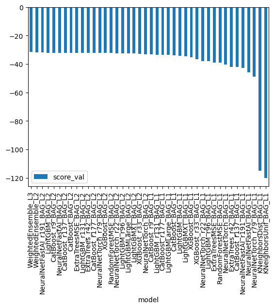

```python
predictor_new_hpo.leaderboard(silent=True).plot(kind="bar", x="model", y="score_val")
```

```python
predictions_new_hpo = predictor_new_hpo.predict(test)
```

```python
predictions_new_hpo.describe()
```

```
count    6493.000000
mean      188.364197
std       171.742416
min         2.451270
25%        45.867943
50%       145.131485
75%       278.176605
max       892.219727
Name: count, dtype: float64
```

```python
# Remember to set all negative values to zero

# How many negative values do we have?
neg_count = 0
for prediction in list(predictions_new_hpo):
    if prediction < 0:
        neg_count += 1
print(neg_count)
```

```
0
```

```python
# handle negative values

# no need to do this

# predictions_new_hpo = predictions_new_hpo.clip(lower=0)
```

```python
# check negative value count again

# no need to do this

"""
neg_count = 0
for prediction in list(predictions_new_hpo):
    if prediction < 0:
        neg_count += 1
print(neg_count)
"""
```

```python
# Same submitting predictions
submission_new_hpo = pd.read_csv('sampleSubmission.csv')

submission_new_hpo["count"] = predictions_new_hpo
submission_new_hpo["count"] = submission_new_hpo["count"].astype("int")

submission_new_hpo.to_csv("submission_new_hpo.csv", index=False)
```

```python
!kaggle competitions submit -c bike-sharing-demand -f submission_new_hpo.csv -m "new features with hyperparameters"
```

```
Successfully submitted to Bike Sharing Demand
```

```python
!kaggle competitions submissions -c bike-sharing-demand | tail -n +1 | head -n 5
```

```
fileName                     date                 description                        status    publicScore  privateScore
---------------------------  -------------------  ---------------------------------  --------  -----------  ------------
submission_new_hpo.csv       2024-09-27 15:29:25  new features with hyperparameters  complete  0.44636      0.44636
submission_new_features.csv  2024-09-27 14:50:44  new features                       complete  0.44354      0.44354
submission.csv               2024-09-27 00:58:35  first raw submission               complete  1.83797      1.83797
```